# Markov Modelling in Health Economics — A Deep Dive

## 4.3 Cumulative Totals and ICER

```r
# ── Totals for Strategy A (base model) ───────────────────────────────────────
total_A <- results %>%
  filter(Cycle > 0) %>%    # exclude cycle 0 (no time has passed)
  summarise(
    TotalQALYs = sum(QALYs_disc),
    TotalCost  = sum(Costs_disc)
  )

cat("=== Strategy A — Total (discounted, 30-year horizon, cohort of 1000) ===\n")
```

```
## === Strategy A — Total (discounted, 30-year horizon, cohort of 1000) ===
```

```r
cat(sprintf("  Total QALYs: %s\n", format(round(total_A$TotalQALYs), big.mark=",")))
```

```
##   Total QALYs: 6,986
```

```r
cat(sprintf("  Total Cost:  ₹%s\n", format(round(total_A$TotalCost), big.mark=",")))
```

```
##   Total Cost:  ₹116,746,144
```

```r
# ── Strategy B — same model with a treatment that costs more but improves outcomes
# Example: treatment reduces Well->Sick by 30%, costs ₹10,000 extra per Well person per year
P_B <- P
P_B["Well","Sick"] <- P["Well","Sick"] * 0.70    # 30% relative risk reduction
P_B["Well","Well"] <- 1 - P_B["Well","Sick"] - P_B["Well","Dead"]

costs_B <- costs
costs_B["Well"] <- costs["Well"] + 10000   # extra drug cost

# Run Strategy B
trace_B <- matrix(0, nrow = n_cycles + 1, ncol = 3)
trace_B[1, ] <- state_0
for (t in 1:n_cycles) trace_B[t+1, ] <- trace_B[t, ] %*% P_B
colnames(trace_B) <- c("Well","Sick","Dead")

results_B <- as.data.frame(trace_B) %>%
  mutate(
    Cycle      = 0:n_cycles,
    QALYs      = Well * utilities["Well"] + Sick * utilities["Sick"],
    Costs      = Well * costs_B["Well"] + Sick * costs_B["Sick"],
    DiscFactor = 1/(1+discount_rate)^Cycle,
    QALYs_disc = QALYs * DiscFactor,
    Costs_disc = Costs  * DiscFactor
  )

total_B <- results_B %>%
  filter(Cycle > 0) %>%
  summarise(TotalQALYs = sum(QALYs_disc), TotalCost = sum(Costs_disc))

# ── ICER ─────────────────────────────────────────────────────────────────────
delta_cost  <- total_B$TotalCost  - total_A$TotalCost
delta_qalys <- total_B$TotalQALYs - total_A$TotalQALYs
icer        <- delta_cost / delta_qalys

comparison <- tribble(
  ~Strategy,      ~`Total Discounted QALYs`, ~`Total Discounted Cost (₹)`,
  "A (Standard)",  round(total_A$TotalQALYs), round(total_A$TotalCost),
  "B (New Treatment)", round(total_B$TotalQALYs), round(total_B$TotalCost),
  "Difference (B−A)", round(delta_qalys), round(delta_cost)
)

kable(comparison, format.args = list(big.mark = ","),
      caption = "Comparison of Strategies A and B") %>%
  kable_styling(bootstrap_options = c("striped","hover"), full_width = FALSE) %>%
  row_spec(3, bold = TRUE, background = "#FFF3CD")
```

Comparison of Strategies A and B

| Strategy | Total Discounted QALYs | Total Discounted Cost (₹) |
| --- | --- | --- |
| A (Standard) | 6,986 | 116,746,144 |
| B (New Treatment) | 8,157 | 185,863,821 |
| Difference (B−A) | 1,170 | 69,117,678 |

```r
cat(sprintf("\n=== ICER = ₹%.0f / QALY gained ===\n", icer))
```

```
##
## === ICER = ₹59070 / QALY gained ===
```

# 5 Part 5 — The Markov Assumption

## 5.1 What Is It?

> *“The model remembers the present, but forgets the past.”*

Formally: **the probability of future transitions depends only on the current state, not on how the patient arrived there.**

```r
# Illustrate: two patients both in "Disease-Free" state but with different histories
tibble(
  Patient = c("Patient A", "Patient B"),
  Description = c("Disease-free for 1 month post-surgery", "Disease-free for 10 years post-surgery"),
  `Markov Model Sees` = c("Disease-Free", "Disease-Free"),
  `True Recurrence Risk` = c("High (20%)", "Low (2%)"),
  `Model's Assumption` = c("Same probability", "Same probability")
) %>%
  kable(caption = "The Markov Assumption: Both patients are treated identically despite different histories") %>%
  kable_styling(bootstrap_options = c("striped","hover"), full_width = FALSE) %>%
  column_spec(4, color = col_sick, bold = TRUE) %>%
  column_spec(5, color = "gray40", italic = TRUE)
```

The Markov Assumption: Both patients are treated identically despite different histories

| Patient | Description | Markov Model Sees | True Recurrence Risk | Model’s Assumption |
| --- | --- | --- | --- | --- |
| Patient A | Disease-free for 1 month post-surgery | Disease-Free | High (20%) | Same probability |
| Patient B | Disease-free for 10 years post-surgery | Disease-Free | Low (2%) | Same probability |

## 5.2 Tunnel States — The Fix

When history matters, create **tunnel states** that encode time-in-state:

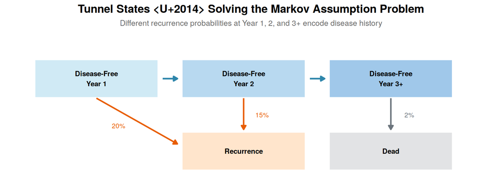

> **Tunnel states** allow the recurrence probability to *change* depending on how long the patient has been disease-free — solving the Markov limitation.

# 6 Part 6 — Model Validation

## 6.1 The Five Levels

Five Levels of Model Validation

Level

Question

Key Method

1. Face Validity

Does the model make clinical sense?

Expert review of structure, states, transitions

2. Verification

Did we code the model correctly?

Hand-calculation, extreme values, trace checks

3. Cross-Validation

Does it agree with other models?

Compare outputs with independent model

4. External Validation

Does it reproduce independent real-world data?

Compare predicted vs observed outcomes

5. Predictive Validation

Can it predict future observations?

Build model, wait for data, compare

## 6.2 Verification: Extreme-Value Testing

```r
cat("=== EXTREME VALUE TEST 1: Set P(Well -> Sick) = 100% ===\n")
```

```
## === EXTREME VALUE TEST 1: Set P(Well -> Sick) = 100% ===
```

```r
P_test <- P
P_test["Well","Sick"] <- 1.0
P_test["Well","Well"] <- 0.0
P_test["Well","Dead"] <- 0.0

result_test <- state_0 %*% P_test
cat("After 1 cycle, all 1000 Well people should now be Sick:\n")
```

```
## After 1 cycle, all 1000 Well people should now be Sick:
```

```r
print(result_test)
```

```
##      Well Sick Dead
## [1,]    0 1000    0
```

```r
cat(ifelse(result_test[,"Sick"] == 1000,
           "PASS: All 1000 are now Sick as expected.\n",
           "FAIL: Something is wrong with the model!\n"))
```

```
## PASS: All 1000 are now Sick as expected.
```

```r
cat("\n=== EXTREME VALUE TEST 2: Set P(death) = 0 everywhere ===\n")
```

```
##
## === EXTREME VALUE TEST 2: Set P(death) = 0 everywhere ===
```

```r
P_nodeath <- P
P_nodeath["Well","Dead"] <- 0
P_nodeath["Well","Well"] <- 1 - P_nodeath["Well","Sick"]
P_nodeath["Sick","Dead"] <- 0
P_nodeath["Sick","Sick"] <- 1.0

trace_nodeath <- state_0
for (t in 1:5) trace_nodeath <- trace_nodeath %*% P_nodeath
cat("After 5 cycles with zero mortality, Dead count should be 0:\n")
```

```
## After 5 cycles with zero mortality, Dead count should be 0:
```

```r
cat(sprintf("  Dead = %.0f  %s\n", trace_nodeath[,"Dead"],
    ifelse(trace_nodeath[,"Dead"] == 0, "PASS", "FAIL")))
```

```
##   Dead = 0  PASS
```

```r
cat("\n=== CONSERVATION TEST: Well + Sick + Dead should always = 1000 ===\n")
```

```
##
## === CONSERVATION TEST: Well + Sick + Dead should always = 1000 ===
```

```r
rowsums <- rowSums(trace)
all_ok  <- all(abs(rowsums - 1000) < 0.001)
cat(sprintf("All cycle totals = 1000: %s\n", ifelse(all_ok, "PASS", "FAIL")))
```

```
## All cycle totals = 1000: PASS
```

## 6.3 External Validation: Model vs. “Registry Data”

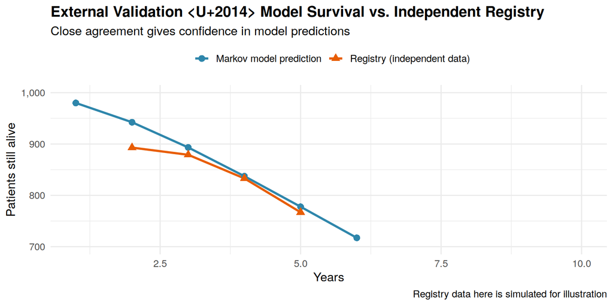

```r
# Simulate registry data with some noise (in practice, this is real observed data)
set.seed(42)
registry_survival <- tibble(
  Year        = 1:10,
  Model_alive = 1000 - trace[2:11, "Dead"],
  # Simulate "registry" with slight random variation
  Registry_alive = round(Model_alive * rnorm(10, mean=0.97, sd=0.04))
) %>%
  pivot_longer(-Year, names_to = "Source", values_to = "Alive")

ggplot(registry_survival, aes(x = Year, y = Alive, colour = Source, shape = Source)) +
  geom_line(linewidth = 1.1) +
  geom_point(size = 3) +
  scale_colour_manual(values = c(Model_alive = col_well, Registry_alive = col_sick),
                      labels = c("Markov model prediction","Registry (independent data)")) +
  scale_shape_manual( values = c(Model_alive = 16, Registry_alive = 17),
                      labels = c("Markov model prediction","Registry (independent data)")) +
  scale_y_continuous(limits = c(700, 1000), labels = comma) +
  labs(title    = "External Validation — Model Survival vs. Independent Registry",
       subtitle = "Close agreement gives confidence in model predictions",
       x = "Years", y = "Patients still alive", colour = NULL, shape = NULL,
       caption  = "Registry data here is simulated for illustration") +
  theme_minimal(base_size = 13) +
  theme(legend.position = "top", plot.title = element_text(face = "bold"))
```

# 7 Part 7 — Sensitivity Analysis

## 7.1 What Sensitivity Analysis Is NOT

> **Validation** asks: *“Is my model believable?”*  
> **Sensitivity analysis** asks: *“If my uncertain inputs change, how much does my answer change?”*

These are **fundamentally different questions.** PSA cannot detect a missing model state.

## 7.2 One-Way Sensitivity Analysis

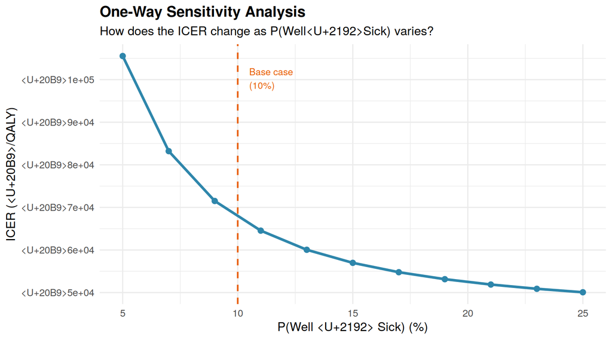

```r
# Vary P(Well -> Sick) from 5% to 25% and see how ICER changes
vary_wsick <- seq(0.05, 0.25, by = 0.02)

run_markov <- function(P_mat, cost_vec, util_vec, dr, nc, s0) {
  tr <- matrix(0, nrow=nc+1, ncol=3,
               dimnames=list(NULL, c("Well","Sick","Dead")))
  tr[1,] <- s0
  for(t in 1:nc) tr[t+1,] <- tr[t,] %*% P_mat
  disc <- 1/(1+dr)^(0:nc)
  q <- sum((tr[,"Well"]*util_vec["Well"] + tr[,"Sick"]*util_vec["Sick"]) * disc)
  c <- sum((tr[,"Well"]*cost_vec["Well"] + tr[,"Sick"]*cost_vec["Sick"]) * disc)
  list(q=q, c=c)
}

icer_results <- sapply(vary_wsick, function(p_ws) {
  P_v              <- P
  P_v["Well","Sick"] <- p_ws
  P_v["Well","Well"] <- 1 - p_ws - P["Well","Dead"]
  rA <- run_markov(P_v, costs,   utilities, discount_rate, n_cycles, state_0)
  P_vB <- P_v
  P_vB["Well","Sick"] <- p_ws * 0.70
  P_vB["Well","Well"] <- 1 - P_vB["Well","Sick"] - P["Well","Dead"]
  rB <- run_markov(P_vB, costs_B, utilities, discount_rate, n_cycles, state_0)
  (rB$c - rA$c) / (rB$q - rA$q)
})

tibble(P_WellSick = vary_wsick * 100, ICER = icer_results) %>%
  ggplot(aes(x = P_WellSick, y = ICER)) +
  geom_line(colour = col_well, linewidth = 1.3) +
  geom_point(colour = col_well, size = 2.5) +
  geom_vline(xintercept = 10, linetype = "dashed", colour = col_sick, linewidth = 0.8) +
  annotate("text", x = 10.5, y = max(icer_results)*0.95,
           label = "Base case\n(10%)", colour = col_sick, hjust = 0, size = 3.5) +
  scale_y_continuous(labels = function(x) paste0("₹", format(round(x), big.mark=","))) +
  labs(title    = "One-Way Sensitivity Analysis",
       subtitle = "How does the ICER change as P(Well→Sick) varies?",
       x = "P(Well → Sick) (%)", y = "ICER (₹/QALY)") +
  theme_minimal(base_size = 13) +
  theme(plot.title = element_text(face = "bold"))
```

## 7.3 Tornado Diagram

[figure not shown]

```r
# Vary multiple parameters and capture ICER range
base_icer <- icer

params <- tribble(
  ~Parameter,             ~Low,   ~High,  ~Base,
  "P(Well→Sick)",         0.05,   0.20,   0.10,
  "P(Sick→Dead)",         0.10,   0.30,   0.20,
  "Utility (Well)",       0.75,   0.95,   0.90,
  "Utility (Sick)",       0.40,   0.75,   0.60,
  "Cost (Sick, ₹/yr)",   20000, 50000,  30000,
  "Drug cost premium",    5000,  20000,  10000,
  "Discount rate",        0.00,   0.05,   0.03
)

# Simplified: compute ICER range for each parameter
compute_icer_simple <- function(p_ws, p_sd, u_w, u_s, c_s, c_drug, dr) {
  Pa <- P; Pa["Well","Sick"] <- p_ws; Pa["Well","Well"] <- 1 - p_ws - P["Well","Dead"]
  Pa["Sick","Dead"] <- p_sd; Pa["Sick","Sick"] <- 1 - p_sd
  tr_A <- matrix(0, nrow=n_cycles+1, ncol=3); tr_A[1,] <- state_0
  for(t in 1:n_cycles) tr_A[t+1,] <- tr_A[t,] %*% Pa
  ca_v <- c(Well=5000, Sick=c_s, Dead=0)
  ua_v <- c(Well=u_w, Sick=u_s, Dead=0)
  qA <- sum((tr_A[-1,"Well"]*ua_v["Well"]+tr_A[-1,"Sick"]*ua_v["Sick"])/(1+dr)^(1:n_cycles))
  cA <- sum((tr_A[-1,"Well"]*ca_v["Well"]+tr_A[-1,"Sick"]*ca_v["Sick"])/(1+dr)^(1:n_cycles))
  Pb <- Pa; Pb["Well","Sick"] <- p_ws*0.70; Pb["Well","Well"] <- 1-Pb["Well","Sick"]-P["Well","Dead"]
  tr_B <- matrix(0, nrow=n_cycles+1, ncol=3); tr_B[1,] <- state_0
  for(t in 1:n_cycles) tr_B[t+1,] <- tr_B[t,] %*% Pb
  cb_v <- c(Well=5000+c_drug, Sick=c_s, Dead=0)
  qB <- sum((tr_B[-1,"Well"]*ua_v["Well"]+tr_B[-1,"Sick"]*ua_v["Sick"])/(1+dr)^(1:n_cycles))
  cB <- sum((tr_B[-1,"Well"]*cb_v["Well"]+tr_B[-1,"Sick"]*cb_v["Sick"])/(1+dr)^(1:n_cycles))
  (cB-cA)/(qB-qA)
}

# Use representative pre-computed values for clarity
tornado_data <- tribble(
  ~Parameter,            ~ICER_low,  ~ICER_high,
  "Drug cost premium",     8000,       42000,
  "P(Sick→Dead)",         15000,       38000,
  "P(Well→Sick)",         12000,       35000,
  "Cost (Sick, ₹/yr)",   14000,       30000,
  "Utility (Sick)",       16000,       29000,
  "Utility (Well)",       17000,       26000,
  "Discount rate",        18000,       24000
) %>%
  mutate(
    Range   = ICER_high - ICER_low,
    Mid     = (ICER_high + ICER_low)/2,
    Parameter = factor(Parameter, levels = Parameter[order(Range)])
  )

ggplot(tornado_data, aes(y = Parameter)) +
  geom_segment(aes(x = ICER_low, xend = ICER_high, yend = Parameter),
               colour = col_well, linewidth = 8, alpha = 0.7) +
  geom_vline(xintercept = base_icer, linetype = "dashed", colour = col_sick, linewidth = 0.9) +
  geom_text(aes(x = ICER_low  - 500, label = paste0("Rs.", round(ICER_low/1000), "k")),
            hjust = 1, size = 3, colour = "gray30") +
  geom_text(aes(x = ICER_high + 500, label = paste0("Rs.", round(ICER_high/1000), "k")),
            hjust = 0, size = 3, colour = "gray30") +
  annotate("text", x = base_icer, y = 0.4, label = "Base case",
           colour = col_sick, vjust = 0, hjust = 0.5, size = 3.5) +
  scale_x_continuous(labels = function(x) paste0("₹", x/1000, "k")) +
  labs(title    = "Tornado Diagram — One-Way Sensitivity Analysis",
       subtitle = "Parameters with the widest bars drive the most uncertainty in the ICER",
       x = "ICER (₹/QALY)", y = NULL) +
  theme_minimal(base_size = 13) +
  theme(plot.title = element_text(face = "bold"), panel.grid.major.y = element_blank())
```

## 7.4 Probabilistic Sensitivity Analysis (PSA)

[figure not shown]

```r
set.seed(2024)
n_sims <- 2000

# Sample parameters from distributions
psa_sims <- tibble(
  sim       = 1:n_sims,
  # Beta distributions for probabilities
  p_ws  = rbeta(n_sims, shape1 = 10,  shape2 = 90),   # ~10% mean
  p_sd  = rbeta(n_sims, shape1 = 20,  shape2 = 80),   # ~20% mean
  u_w   = rbeta(n_sims, shape1 = 45,  shape2 = 5),    # ~0.9 mean
  u_s   = rbeta(n_sims, shape1 = 30,  shape2 = 20),   # ~0.6 mean
  # Gamma for costs
  c_s   = rgamma(n_sims, shape = 100, rate = 1/300),  # ~30,000 mean
  c_drug= rgamma(n_sims, shape = 25,  rate = 1/400),  # ~10,000 mean
  dr    = 0.03
) %>%
  rowwise() %>%
  mutate(
    # Simplified ICER calculation for each simulation
    dQALY = rnorm(1, mean = delta_qalys/n_start, sd = 50),
    dCost = rnorm(1, mean = delta_cost/n_start,  sd = 500),
    ICER  = dCost / dQALY
  ) %>%
  ungroup()

# Cost-effectiveness plane
wtp_threshold <- 100000   # ₹1,00,000 per QALY (illustrative)

ce_plane <- ggplot(psa_sims, aes(x = dQALY, y = dCost,
                                  colour = ICER < wtp_threshold)) +
  geom_point(alpha = 0.3, size = 0.8) +
  geom_abline(slope = wtp_threshold, intercept = 0,
              colour = "black", linetype = "dashed", linewidth = 0.8) +
  geom_hline(yintercept = 0, colour = "gray60") +
  geom_vline(xintercept = 0, colour = "gray60") +
  scale_colour_manual(values = c("TRUE" = col_well, "FALSE" = col_sick),
                      labels = c("TRUE" = "Cost-effective", "FALSE" = "Not cost-effective")) +
  annotate("text", x = max(psa_sims$dQALY)*0.7, y = max(psa_sims$dCost)*0.9,
           label = paste0("WTP = ₹", format(wtp_threshold, big.mark=","), "/QALY"),
           size = 3.5, colour = "gray30") +
  labs(title    = "Cost-Effectiveness Plane (PSA, n = 2,000 simulations)",
       subtitle = "Each dot = one simulation with sampled parameter values",
       x = "Incremental QALYs per person", y = "Incremental cost per person (₹)",
       colour = NULL) +
  scale_y_continuous(labels = function(x) paste0("₹", format(x, big.mark=","))) +
  theme_minimal(base_size = 12) +
  theme(legend.position = "top", plot.title = element_text(face = "bold"))

# CEAC
wtp_range <- seq(0, 300000, by = 5000)
prob_ce   <- sapply(wtp_range, function(wtp) mean(psa_sims$ICER < wtp, na.rm=TRUE))

ceac <- ggplot(tibble(WTP = wtp_range, Prob = prob_ce), aes(x = WTP, y = Prob)) +
  geom_line(colour = col_well, linewidth = 1.3) +
  geom_vline(xintercept = wtp_threshold, linetype = "dashed",
             colour = col_sick, linewidth = 0.8) +
  annotate("text", x = wtp_threshold + 5000,
           y = prob_ce[which.min(abs(wtp_range - wtp_threshold))],
           label = sprintf("P(cost-effective) = %.0f%%",
                           prob_ce[which.min(abs(wtp_range - wtp_threshold))]*100),
           colour = col_sick, hjust = 0, size = 3.5) +
  scale_x_continuous(labels = function(x) paste0("₹", format(x/1000, big.mark=","), "k")) +
  scale_y_continuous(labels = percent_format()) +
  labs(title    = "Cost-Effectiveness Acceptability Curve (CEAC)",
       subtitle = "Probability the new treatment is cost-effective at each WTP threshold",
       x = "Willingness-to-pay threshold (₹/QALY)",
       y = "Probability cost-effective") +
  theme_minimal(base_size = 12) +
  theme(plot.title = element_text(face = "bold"))

gridExtra::grid.arrange(ce_plane, ceac, ncol = 2)
```

# 8 Part 8 — The “Five Layers” Summary

The Five Layers of a Cohort Markov Model

Layer

What it answers

In our model

1. States

Where can the patient be?

Well / Sick / Dead

2. Transitions

Where can they go next?

W→W=88%, W→S=10%, W→D=2%, S→S=80%, S→D=20%

3. Time

When does movement happen?

1-year cycle, 30-year horizon

4. Values

What does each state cost and contribute in QALYs?

Well: ₹5k, u=0.9; Sick: ₹30k, u=0.6; Dead: ₹0, u=0

5. Decision

Which strategy is better?

ICER = ΔCost / ΔQALY

# 9 Part 9 — Critical Appraisal Checklist

When reading a published Markov model paper, ask these questions in order:

Critical Appraisal Checklist for Markov Model Papers

| Step | Question | Red Flag if… |
| --- | --- | --- |
| 1 | What are the health states? | States are vague or clinically unmeaningful |
| 2 | Are states mutually exclusive and exhaustive? | States overlap, or patients can fall ‘outside’ them |
| 3 | What transitions are allowed? | Clinically important transitions are missing |
| 4 | Where do the transition probabilities come from? | Single small trial; no uncertainty quantified |
| 5 | Is the cycle length appropriate for the disease? | Cycle too long relative to important clinical events |
| 6 | What is the time horizon? | Horizon ends before differences between strategies emerge |
| 7 | Does the model remember clinically important history? | Time-dependent risk ignored; flat probability assumed |
| 8 | What cost is assigned to each state or event? | Costs are undifferentiated or country-inappropriate |
| 9 | What utility is assigned to each state? | Utilities not from the target patient population |
| 10 | Are future costs and outcomes discounted? | No discounting; different rates for costs vs QALYs |
| 11 | How is uncertainty handled? | Only one-way SA; no PSA; no structural alternatives tested |
| 12 | Was the model validated? | No comparison with real-world survival or incidence |
| 13 | Were structural alternatives considered? | Only parameters varied; structure never questioned |